# Stat490_HW4

Janine Yanes

```r
knitr::opts_chunk$set(results = 'asis')
#Load packages
library(knitr)
library(kableExtra)
library(tidyverse)
library(combinat)
```

## Problem 1

### (i)

```r
PTSDdat = matrix(scan("ptsd.txt"), ncol=2, byrow=T)
y = PTSDdat[,2]
w = PTSDdat[,1]

anova(lm(y ~ factor(w)))
```

```
## Analysis of Variance Table
##
## Response: y
##           Df  Sum Sq Mean Sq F value  Pr(>F)
## factor(w)  3  507.84 169.280  3.0458 0.03936 *
## Residuals 41 2278.74  55.579
## ---
## Signif. codes:  0 '***' 0.001 '**' 0.01 '*' 0.05 '.' 0.1 ' ' 1
```

|  | Df | Sum Sq | Mean Sq | F value |
| --- | --- | --- | --- | --- |
| **Treatments** | 3 | 507.84 | 169.28 | 3.046 |
| **Residuals** | 41 | 2278.74 | 55.58 |  |
| **Total** | 44 | 2786.58 | 224.86 |  |

```r
Fobs = anova(lm(y ~ factor(w)))[[4]][[1]]
cat("The observed F-statistic is ", Fobs, ".", sep="")
```

The observed F-statistic is 3.045757.

### (ii)

```r
set.seed(123)
Farray = NULL
w = c(rep(1,14),rep(2,10),rep(3,11),rep(4,10))
exactw = unique(permn(w)) #too many permutations to calculate all of them
```

```
## Error in vector("list", gamma(n + 1)): vector size specified is too large
```

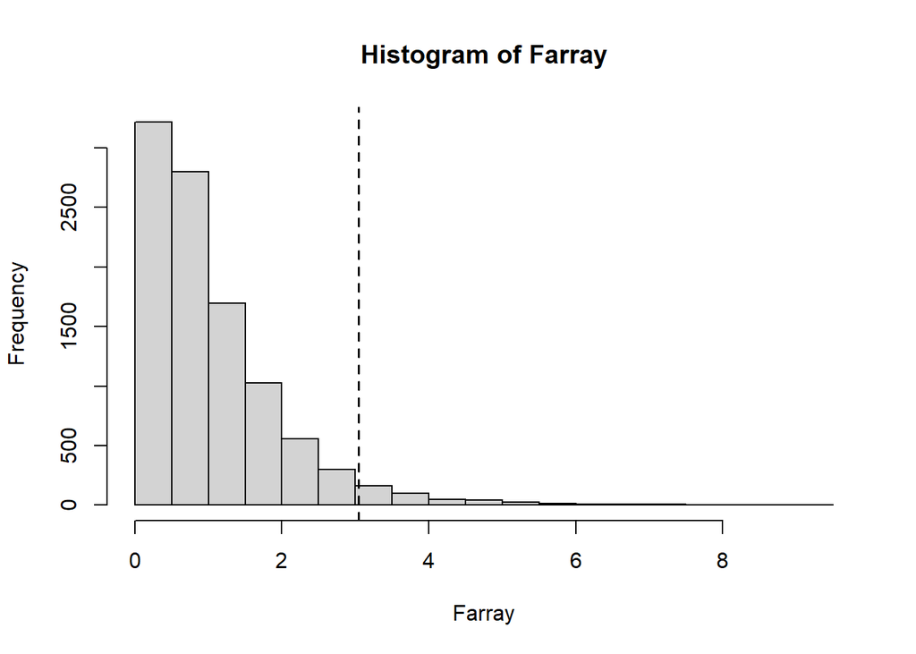

```r
for (i in 1:10000){
  wnew = sample(c(rep(1,14),rep(2,10),rep(3,11),rep(4,10)))
  Fnew = anova(lm(y ~ factor(wnew)))[[4]][[1]]
  Farray = c(Farray, Fnew)
}

hist(Farray)
abline(v=Fobs, lty=2, lwd=1.5)
```

```r
pval = sum(Farray > Fobs)/10000
pval
```

[1] 0.0391

### (iii)

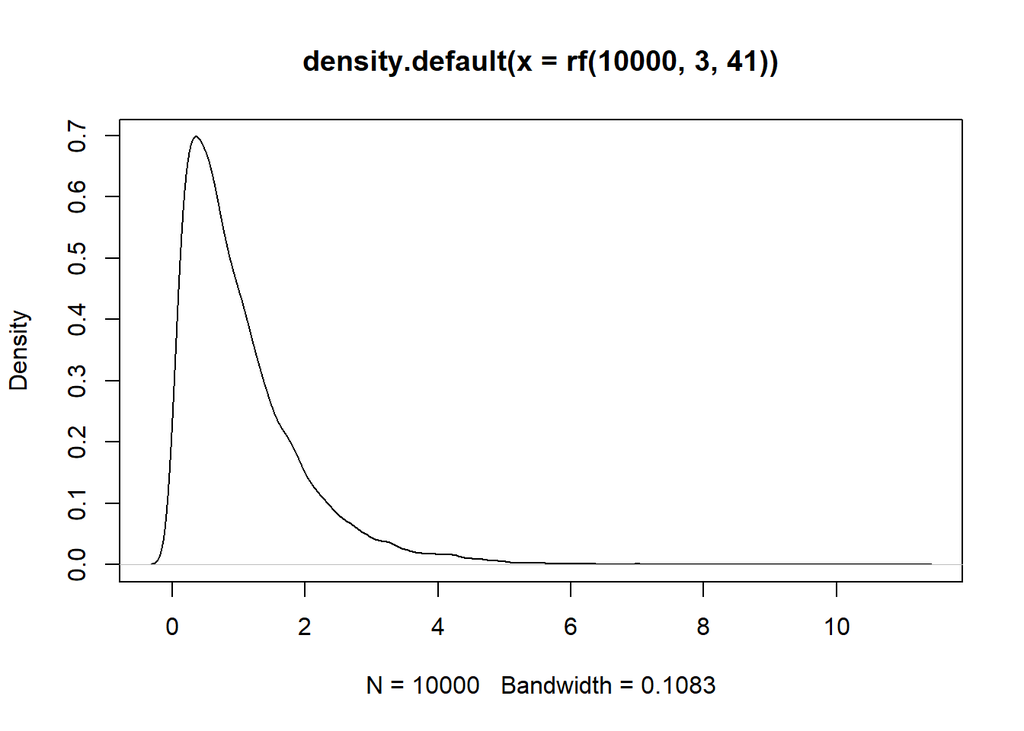

```r
plot(density(rf(10000,3,41)))
```

```r
approx_pval = 1 - pf(Fobs,3,41)
approx_pval
```

[1] 0.03936265

### (iv)

Testing the hypotheses:  
$H_0:\tau_i(1,2) = 0$ for $i = 1, 2, \dots, 45$  
$H_0:\tau_i(1,3) = 0$ for $i = 1, 2, \dots, 45$  
$H_0:\tau_i(1,4) = 0$ for $i = 1, 2, \dots, 45$  
$H_0:\tau_i(2,3) = 0$ for $i = 1, 2, \dots, 45$  
$H_0:\tau_i(2,4) = 0$ for $i = 1, 2, \dots, 45$  
$H_0:\tau_i(3,4) = 0$ for $i = 1, 2, \dots, 45$  
6 pairs, so the ensemble-adjusted p-value is $p^*/\binom{J}{2} = 0.05/6 = 0.0083$

```r
PTSD_df = data.frame(treatment = PTSDdat[,1], PTSDscore = PTSDdat[,2])
y_1_2 = subset(PTSD_df, treatment == 1 | treatment == 2)$PTSDscore
y_1_3 = subset(PTSD_df, treatment == 1 | treatment == 3)$PTSDscore
y_1_4 = subset(PTSD_df, treatment == 1 | treatment == 4)$PTSDscore
y_2_3 = subset(PTSD_df, treatment == 2 | treatment == 3)$PTSDscore
y_2_4 = subset(PTSD_df, treatment == 2 | treatment == 4)$PTSDscore
y_3_4 = subset(PTSD_df, treatment == 3 | treatment == 4)$PTSDscore
w_1_2 = subset(PTSD_df, treatment == 1 | treatment == 2)$treatment
w_1_3 = subset(PTSD_df, treatment == 1 | treatment == 3)$treatment
w_1_4 = subset(PTSD_df, treatment == 1 | treatment == 4)$treatment
w_2_3 = subset(PTSD_df, treatment == 2 | treatment == 3)$treatment
w_2_4 = subset(PTSD_df, treatment == 2 | treatment == 4)$treatment
w_3_4 = subset(PTSD_df, treatment == 3 | treatment == 4)$treatment

# (a) Neymanian
#Given the contrast bar_tau_star = Y-bar(j) - Y_bar(j2)
Neymanian_inference = function(y, w, j, j2, alpha){
  y_j = y[w == j]
  y_j2 = y[w == j2]
  Nj = length(y_j)
  Nj2 = length(y_j2)
  sjsq = (1/(Nj-1)) * sum((y_j - mean(y_j))^2)
  sj2sq = (1/(Nj2-1)) * sum((y_j2 - mean(y_j2))^2)
  taustar_bar_hat = mean(y_j) - mean(y_j2)
  var_unpooled_hat = sjsq/Nj + sj2sq/Nj2
  z = qnorm(1 - alpha/2)
  return(c(taustar_bar_hat - z*sqrt(var_unpooled_hat), taustar_bar_hat + z*sqrt(var_unpooled_hat)))
}

Neymanian_inference(y_1_2,w_1_2, 1, 2, 0.05)
```

[1] -11.523266 2.866123

```r
Neymanian_inference(y_1_3,w_1_3, 1, 3, 0.05)
```

[1] -11.715809 -2.323152

```r
Neymanian_inference(y_1_4,w_1_4, 1, 4, 0.05)
```

[1] -13.295045 -3.562098

```r
Neymanian_inference(y_2_3,w_2_3, 2, 3, 0.05)
```

[1] -10.768826 5.387007

```r
Neymanian_inference(y_2_4,w_2_4, 2, 4, 0.05)
```

[1] -12.278007 4.078007

```r
Neymanian_inference(y_3_4,w_3_4, 3, 4, 0.05)
```

[1] -7.505948 4.687766

According to the Neymanian method, treatment pairs (1,3) and (1,4) have a significant difference at the 0.05 level (using the ensemble-adjusted p-value), since the 95% confidence intervals for their respective contrasts do not include 0.

```r
# (b) Randomization approach
set.seed(123)
Fobs = anova(lm(y_1_2 ~ factor(w_1_2)))[[4]][[1]]
Farray = NULL
for (i in 1:5000){
  wnew_1_2 = sample(c(rep(1,14),rep(2,10)))
  Fnew = anova(lm(y_1_2 ~ factor(wnew_1_2)))[[4]][[1]]
  Farray = c(Farray, Fnew)
}
#hist(Farray)
#abline(v=Fobs, lty=2, lwd=1.5)
pval_1_2 = sum(Farray > Fobs)/5000
pval_1_2
```

[1] 0.1896

```r
Fobs = anova(lm(y_1_3 ~ factor(w_1_3)))[[4]][[1]]
Farray = NULL
for (i in 1:5000){
  wnew_1_3 = sample(c(rep(1,14),rep(3,11)))
  Fnew = anova(lm(y_1_3 ~ factor(wnew_1_3)))[[4]][[1]]
  Farray = c(Farray, Fnew)
}
#hist(Farray)
#abline(v=Fobs, lty=2, lwd=1.5)
pval_1_3 = sum(Farray > Fobs)/5000
pval_1_3
```

[1] 0.0062

```r
Fobs = anova(lm(y_1_4 ~ factor(w_1_4)))[[4]][[1]]
Farray = NULL
for (i in 1:5000){
  wnew_1_4 = sample(c(rep(1,14),rep(4,10)))
  Fnew = anova(lm(y_1_4 ~ factor(wnew_1_4)))[[4]][[1]]
  Farray = c(Farray, Fnew)
}
#hist(Farray)
#abline(v=Fobs, lty=2, lwd=1.5)
pval_1_4 = sum(Farray > Fobs)/5000
pval_1_4
```

[1] 0.001

```r
Fobs = anova(lm(y_2_3 ~ factor(w_2_3)))[[4]][[1]]
Farray = NULL
for (i in 1:5000){
  wnew_2_3 = sample(c(rep(2,10), rep(3,11)))
  Fnew = anova(lm(y_2_3 ~ factor(wnew_2_3)))[[4]][[1]]
  Farray = c(Farray, Fnew)
}
#hist(Farray)
#abline(v=Fobs, lty=2, lwd=1.5)
pval_2_3 = sum(Farray > Fobs)/5000
pval_2_3
```

[1] 0.5212

```r
Fobs = anova(lm(y_2_4 ~ factor(w_2_4)))[[4]][[1]]
Farray = NULL
for (i in 1:5000){
  wnew_2_4 = sample(c(rep(2,10), rep(4,10)))
  Fnew = anova(lm(y_2_4 ~ factor(wnew_2_4)))[[4]][[1]]
  Farray = c(Farray, Fnew)
}
#hist(Farray)
#abline(v=Fobs, lty=2, lwd=1.5)
pval_2_4 = sum(Farray > Fobs)/5000
pval_2_4
```

[1] 0.328

```r
Fobs = anova(lm(y_3_4 ~ factor(w_3_4)))[[4]][[1]]
Farray = NULL
for (i in 1:5000){
  wnew_3_4 = sample(c(rep(3,11), rep(4,10)))
  Fnew = anova(lm(y_3_4 ~ factor(wnew_3_4)))[[4]][[1]]
  Farray = c(Farray, Fnew)
}
#hist(Farray)
#abline(v=Fobs, lty=2, lwd=1.5)
pval_3_4 = sum(Farray > Fobs)/5000
pval_3_4
```

[1] 0.6688

According to the randomization approach, treatment pairs (1,3) and (1,4) have a significant difference at the 0.05 level (using the ensemble-adjusted p-value).

## Problem 2

### (i)

One possible problem is that it could be hard to determine the exact moment that a person falls asleep (or wakes up, for that matter): would it be based on when they close their eyes, brainwaves, etc.? As a result, it would be hard to precisely measure how long a person sleeps. Furthermore, considering the times that the algebraic computations have to be performed (at night/early morning), it’s highly likely that the participants’ sleep would have to be interrupted. In other words, even if all the participants end up sleeping their assigned total amount that day, their amount of sleep when performing the computations may differ.

### (ii)

4 different treatment groups, so (J - 1) = (4 - 1) = 3  
24 participants, so (N - J) = (24 - 4) = 20 and (N - 1) = (24 - 1) = 23  
MSRes = SSRes/(N - J) = 469.61/20 = 23.4805  
F = MSTre/MSRes, so MSTre = MSRes(F) = 23.4805(9.101) = 213.696031  
MSTre = SSTre/(J - 1), so SSTre = MSTre(J - 1) = 213.696031(3) = 641.088093  
641.088093 + 469.61 = 1110.698093  
213.696031 + 23.4805 = 237.176531

|  | Df | Sum Sq | Mean Sq | F value |
| --- | --- | --- | --- | --- |
| **Hours of sleep** | 3 | 641.09 | 213.70 | 9.101 |
| **Residuals** | 20 | 469.61 | 23.48 |  |
| **Total** | 23 | 1110.70 | 237.18 |  |

### (iii)

```r
approx_pval_prob2 = 1 - pf(9.101,3,20)
approx_pval_prob2
```

[1] 0.0005298117

## Problem 3

| Block | Unit | Tr. 1 | Tr. 2 | Tr. 3 | Mean |
| --- | --- | --- | --- | --- | --- |
|  | 1 | 5 | 9 | 7 | 7 |
| **Block 1** | 2 | 6 | 10 | 8 | 8 |
|  | 3 | 7 | 11 | 9 | 9 |
|  | *Mean* | 6 | 10 | 8 | 8 |
| — | — | — | — | — | — |
|  | 4 | 7 | 11 | 9 | 9 |
| **Block 2** | 5 | 8 | 12 | 10 | 10 |
|  | 6 | 9 | 13 | 11 | 11 |
|  | *Mean* | 8 | 12 | 10 | 10 |
| — | — | — | — | — | — |
|  | 7 | 3 | 7 | 5 | 5 |
| **Block 3** | 8 | 4 | 8 | 6 | 6 |
|  | 9 | 5 | 9 | 7 | 7 |
|  | *Mean* | 4 | 8 | 6 | 6 |
| — | — | — | — | — | — |
| **Mean** |  | 6 | 10 | 8 | 8 |

### (i)

Block 1: $\bar\tau(1,2) = 6 - 10 = -4, \;\bar\tau(1,3) = 6 - 8 = -2, \; \bar\tau(2,3) = 10 - 8 = 2$  
Block 2: $\bar\tau(1,2) = 8 - 12 = -4, \;\bar\tau(1,3) = 8 - 10 = -2, \;\bar\tau(2,3) = 12 - 10 = 2$  
Block 3: $\bar\tau(1,2) = 4 - 8 = -4, \;\bar\tau(1,3) = 4 - 6 = -2, \;\bar\tau(2,3) = 8 - 6 = 2$  
For all units: $\bar\tau(1,2) = 6 - 10 = -4, \;\bar\tau(6 - 8) = -2, \;\bar\tau(2,3) = 10 - 8 = 2$

### (ii)

Block 1: $\bar\tau(1) = 6 - 8 = -2, \;\bar\tau(2) = 10 - 8 = 2, \;\bar\tau(3) = 8 - 8 = 0$  
Block 2: $\bar\tau(1) = 8 - 10 = -2, \;\bar\tau(2) = 12 - 10 = 2, \;\bar\tau(3) = 10 - 10 = 0$  
Block 3: $\bar\tau(1) = 4 - 6 = -2, \;\bar\tau(2) = 8 - 6 = 2, \;\bar\tau(3) = 6 - 6 = 0$  
For all units: $\bar\tau(1) = 6 - 8 = -2, \;\bar\tau(2) = 10 - 8 = 2, \;\bar\tau(3) = 8 - 8 = 0$

### (iii)

No; the treatment effects within each block are equal to the average unit-level treatment effect, so the interaction effect $\bar\gamma_b$ for each block *b* is 0.

### (iv)

| Block | Unit | Tr. 1 | Tr. 2 | Tr. 3 |
| --- | --- | --- | --- | --- |
|  | 1 | 5 | ? | ? |
| **Block 1** | 2 | ? | ? | 8 |
|  | 3 | ? | 11 | ? |
| — | — | — | — | — |
|  | 4 | ? | 11 | ? |
| **Block 2** | 5 | 8 | ? | ? |
|  | 6 | ? | ? | 11 |
| — | — | — | — | — |
|  | 7 | ? | 7 | ? |
| **Block 3** | 8 | ? | ? | 6 |
|  | 9 | 5 | ? | ? |

### (v)

$\hat{\bar\tau}(j) = \bar y.(j) - \bar y(\cdot) = \frac{1}{N_j}\sum_{i:W_i=j}y_i - \frac{1}{N}\sum_{i=1}^Ny_i$  
Block 1: $\hat{\bar\tau}(1) = 5 - 8 = -3, \;\hat{\bar\tau}(2) = 11 - 8 = 3, \;\hat{\bar\tau}(3) = 8 - 8 = 0$  
Block 2: $\hat{\bar\tau}(1) = 8 - 10 = -2, \;\hat{\bar\tau}(2) = 11 - 10 = 1, \;\hat{\bar\tau}(3) = 11 - 10 = 1$  
Block 3: $\hat{\bar\tau}(1) = 5 - 6 = -1, \;\hat{\bar\tau}(2) = 7 - 6 = 1, \;\hat{\bar\tau}(3) = 6 - 6 = 0$  
For all units: $\hat{\bar\tau}(1) = 6 - 8 = -2, \;\hat{\bar\tau}(2) = 9.6\bar6 - 8 = 1.6\bar6, \;\hat{\bar\tau}(3) = 8.3\bar3 - 8 = 0.3\bar3$

### (vi)

```r
y_prob3 = c(5, 8, 11, 11, 8, 11, 7, 6, 5)
w_prob3 = c(1, 3, 2, 2, 1, 3, 2, 3, 1)

anova(lm(y_prob3 ~ factor(w_prob3)))
```

```
## Analysis of Variance Table
##
## Response: y_prob3
##                 Df Sum Sq Mean Sq F value Pr(>F)
## factor(w_prob3)  2 20.667 10.3333  2.1136 0.2019
## Residuals        6 29.333  4.8889
```

|  | Df | Sum Sq | Mean Sq | F value |
| --- | --- | --- | --- | --- |
| **Treatments** | 2 | 20.67 | 10.33 | 2.114 |
| **Residuals** | 6 | 29.33 | 4.89 |  |
| **Total** | 8 | 50.00 | 15.22 |  |

We are making the assumption that the variance of each block is approximately equal, which is not true in this case.

### (vii)

```r
Fobs_prob3 = anova(lm(y_prob3 ~ factor(w_prob3)))[[4]][[1]]
approx_pval_prob3 = 1 - pf(Fobs_prob3, 2, 6)
approx_pval_prob3
```

[1] 0.2019176

## Problem 4

### (a)

(0,0,0,0,1,1,1,1), (1,1,1,1,0,0,0,0), (0,0,1,1,0,0,1,1), (1,1,0,0,1,1,0,0), (0,1,0,1,0,1,0,1), and (1,0,1,0,1,0,1,0) all divide the units according to the value of a certain covariate (such that it equals 0 for all units assigned to one treatment and equals 1 for all units assigned to the other), making that covariate a confounding variable. We would have no idea if any difference between treatments would be due to the treatments themselves or the difference in the covariate’s values.

### (b)

There are 2 units for each possible $x_1$ and $x_2$ value pair: units (1,2), (3,4), (5,6), and (7,8). Considering this, a matched-pair design could be used: if one unit is assigned to treatment 1, then the unit with the same $x_1$ and $x_2$ values would be assigned to treatment 2. This would have $_2C_1 * _2C_1 * _2C_1 * _2C_1 = 2^4 = 16$ possible randomizations, with the assignment vector (1,1,1,1,0,0,0,0) being impossible under this design.

### (c)

One of the worst assignment vectors would be (0,1,0,1,0,1,0,1) since it would make $x_3$ a confounding variable (as explained in (a)), which is impossible for the other covariates under the matched-pair design. While $x_3$ is not as important as $x_1$ and $x_2$, it could still affect the experiment/outcomes.

### (d)

```r
X = matrix(c(0,0,0,0,1,1,1,1,0,0,1,1,0,0,1,1,0,1,0,1,0,1,0,1), nrow = 8, ncol = 3, dimnames = list(NULL, c("x1","x2","x3")))
X
```

```
##      x1 x2 x3
## [1,]  0  0  0
## [2,]  0  0  1
## [3,]  0  1  0
## [4,]  0  1  1
## [5,]  1  0  0
## [6,]  1  0  1
## [7,]  1  1  0
## [8,]  1  1  1
```

```r
#function from March 25 lecture
MD = function(X,W) {
  N1 = sum(W)
  N0 = sum(1-W)
  N = N1 + N0
  sigmainv = solve(cov(X))
  Xt = X[W==1,]
  Xc = X[W==0,]
  Xtbar = as.vector(apply(Xt,2,mean))
  Xcbar = as.vector(apply(Xc,2,mean))
  MD = (N0*N1)/N * t(Xtbar - Xcbar) %*% sigmainv %*% (Xtbar - Xcbar)
  return(MD)
}

# (i)
w_i = c(1,1,1,1,0,0,0,0)
MD(X, w_i)
```

```
##      [,1]
## [1,]    7
```

```r
# (ii)
w_ii = c(0,1,0,1,0,1,0,1)
MD(X, w_ii)
```

```
##      [,1]
## [1,]    7
```

```r
# (iii)
w_iii = c(0,1,1,0,0,0,1,1)
MD(X, w_iii)
```

```
##      [,1]
## [1,] 1.75
```

Under the acceptance criterion, only the assigment (iii) would be accepted.